# Ever wondered if your dog could become an internet superstar?

If you're like me than you probably have (and I mean which dogowner does not). And you're lucky because there's the great Twitter account [WeRateDogs](https://twitter.com/dog_rates) which, you guessed it, rates your dog! And it comes even better, there's an active community of about 7,7 million followers exchanging love about their dogs! Let's not waste any more time talking and check which dog breed receives the on average highest rating by WeRateDogs.

###### You can display the code for each plot by simply klicking on it .

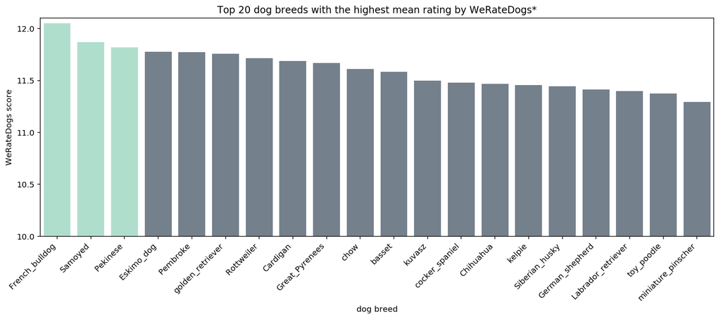

```python
top_predictions = predictions[predictions['confidence_order'] == 1]
# create a counts df which contains the value counts for each dog breed
counts = top_predictions.prediction.value_counts().rename('counts').reset_index()
counts.columns = ['prediction', 'counts']

# merge the counts df with the top predictions df
top_predictions = pd.merge(top_predictions, counts, on = 'prediction')

# only keep dog breeds where the value count is at least 10.
# this ensures that the the plot is not distorted by breeds for which
# only few datapoints exist.
top_predictions = top_predictions[top_predictions['counts'] >= 10]

# merge top_predictions and archive df to have popularity info and prediction in one table
combined = pd.merge(archive, top_predictions, on = 'tweet_id')
# only consider predictions which depict a dog
combined = combined[combined['dog'] == True]

combined_rating = combined.groupby('prediction').mean().sort_values('rating_numerator', ascending = False).reset_index()

clrs = ['#a8e6cf' if (x in list(combined_rating.prediction.head(3)))\
        else base_color for x in combined_rating.prediction]

plt.figure(figsize = (15, 5))
sns.barplot(data = combined_rating.head(20), y = 'rating_numerator', x = 'prediction', palette = clrs)
plt.xticks(rotation = 45, ha = 'right')
plt.ylim(10, 12.1)
plt.yticks(np.arange(10, 12.5, 0.5))
plt.title('Top 20 dog breeds with the highest mean rating by WeRateDogs*')
plt.ylabel('WeRateDogs score')
plt.xlabel('dog breed');
```

* only dog breeds which are present in at least 10 tweets are considered to avoid distortion.

You own a French Bulldog? Great. You officially chose the dog breed which receives the on average highest rating by WeRateDogs! Your dog is not a French Bulldog? Well, it's not the end of the world either, there are many breeds which receive an average rating of 11.5+ and even if not, the most important fact is: your dog still loves you (mine is a Labrador Retriever btw). And there are other catogories to follow where your dog might shine.

#### Having said that, let's check what the community thinks is the most adorable dog breed.

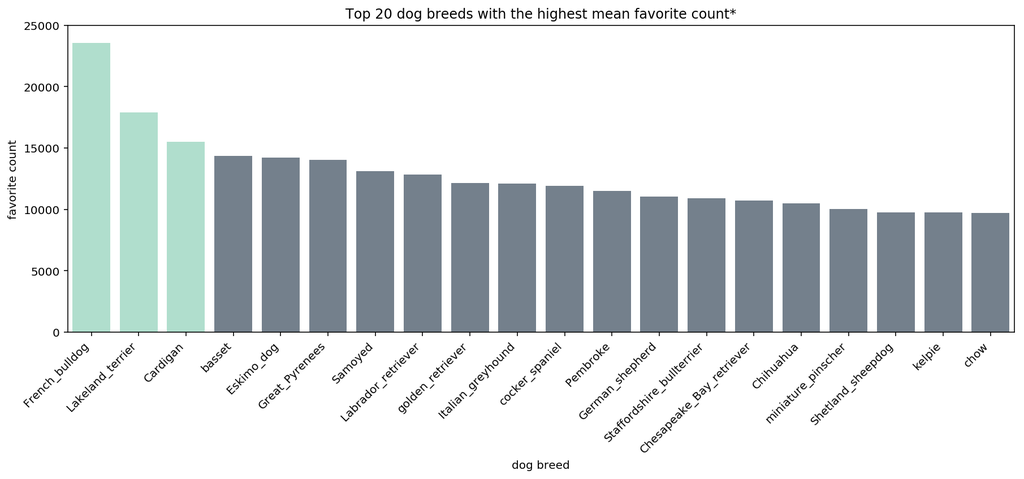

```python
# group the df by prediction and calculate mean, sort by favorite count descending
combined_favorite = combined.groupby('prediction').mean().sort_values('favorite_count', ascending = False).reset_index()

clrs = ['#a8e6cf' if (x in list(combined_favorite.prediction.head(3)))\
        else base_color for x in combined_favorite.prediction]

plt.figure(figsize = (15, 5))
sns.barplot(data = combined_favorite.head(20), y = 'favorite_count', x = 'prediction', palette = clrs)
plt.xticks(rotation = 45, ha = 'right')
plt.ylim(0, 25000)
plt.title('Top 20 dog breeds with the highest mean favorite count*')
plt.ylabel('favorite count')
plt.xlabel('dog breed');
```

* only dog breeds which are present in at least 10 tweets are considered to avoid distortion.

Wow! the French Bulldog strikes again. It even gets the most love from the community. This time it's followed by the Lakeland Terrier and the Cardigan. Ok, so we've seen that WeRateDogs rating and the communities opinion are in line for the most popular dog breed. But can we generalize this observation?

#### Does a high rating by WeRateDogs increase the likelihood of a tweet to become more popular?

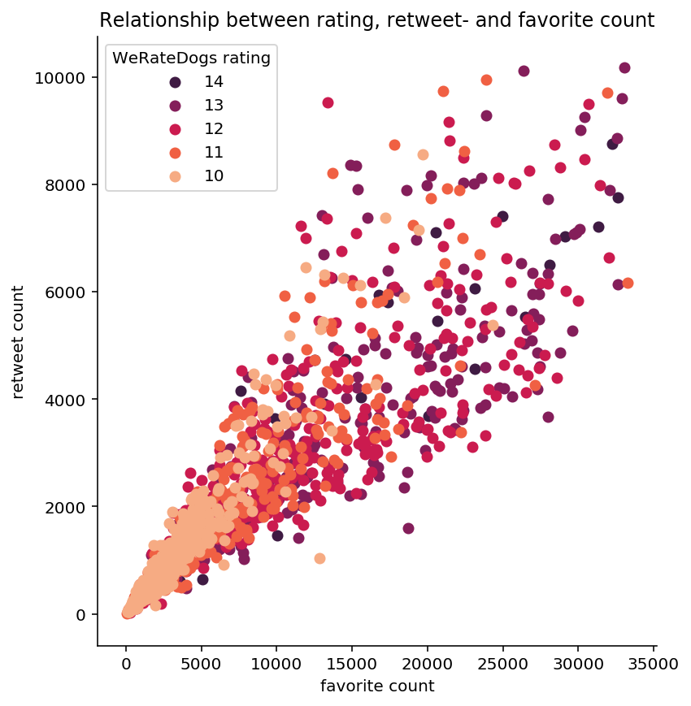

```python
# only plot 95 percentile
data = archive.query('favorite_count < 33302.75 and retweet_count < 10281')

g = sns.FacetGrid(data = data, hue = 'rating_numerator', size = 6,\
                  hue_order = [14, 13, 12, 11, 10], palette = 'rocket')
g.map(plt.scatter, 'favorite_count', 'retweet_count')
plt.xlabel('favorite count')
plt.ylabel('retweet count')
plt.title('Relationship between rating, retweet- and favorite count')
plt.legend(title = 'WeRateDogs rating');
```

First of all, the scatter plot indicates a positive correlation between retweet- and favorite count, meaning that a more favorited tweet is likely to also have a higher retweet count. Second, tweets which receive a higher rating by WeRateDogs tend to be more skewed to the top right indicating that high rated tweets are more likely to go viral. Let's facet the above plot to get a better understanding of the composition.

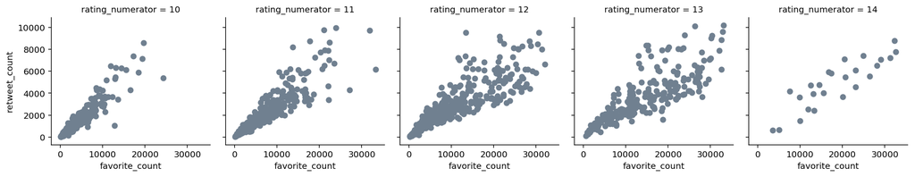

```python
g = sns.FacetGrid(data = data, col = 'rating_numerator')
g.map(plt.scatter, 'favorite_count', 'retweet_count', color = base_color);
```

Now clearly visible is the dispersion of data points towards the top right with the rating increasing. With a rating of 10, the datapoints are skewed towards the bottom left corner whereas datapoints are far more centered and stretch all the way to the top right corner for a rating of 13. Only very few tweets actually receive a rating of 14, indicated by the small amount of datapoints.

But hey, dogs do not only come in different stages, they also evolve through different stages in their lifetime. Here's a quick overview on the different dog stages.

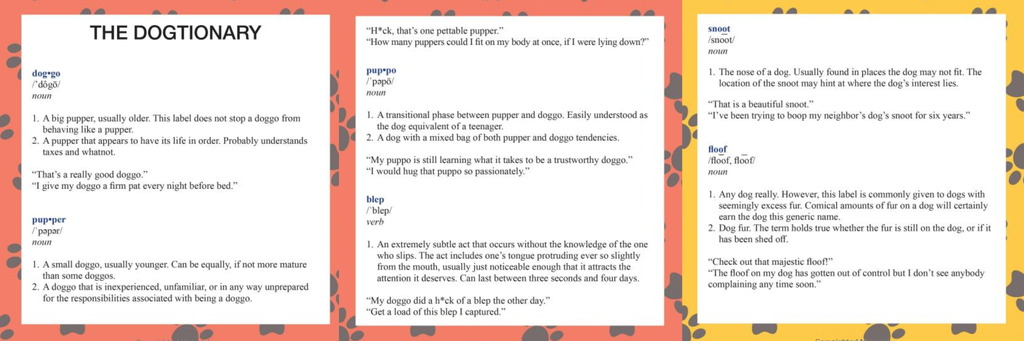

```python
Image('dogtionary-combined.png')
```

#### Leading to the question: Which dog stage is the most tweeted?

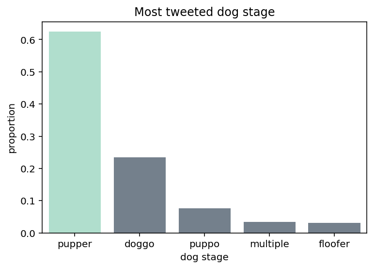

```python
n = archive.dog_stage.count()
n_max = archive.dog_stage.value_counts().max()
p_max = n_max / n
ticks = np.arange(0, p_max, 0.10)
labels = ['{:.1f}'.format(v) for v in ticks]

most_tweets = archive.groupby('dog_stage').size().sort_values(0, ascending = False).reset_index()

clrs = ['#a8e6cf' if (x in list(most_tweets.dog_stage.head(1))) else base_color for x in most_tweets.dog_stage]

sns.countplot(data = archive, x = 'dog_stage', palette = clrs, order = most_tweets.dog_stage)
plt.yticks(ticks * n, labels)
plt.ylabel('proportion')
plt.xlabel('dog stage')
plt.title('Most tweeted dog stage');
```

Puppers are with a share of 60 percent the most tweeted dog stage, followed by doggos with around 25 percent. Puppos and floofers are a lot rarer with each one making up less than 10 percent of all tweets. Some tweets also had images with multiple dogs in multiple stages displayed. (Side note for statistic nerds among you: the dog stage was only specified in 290 tweets. The above plot is a representation of this sample of 290 tweets and not of the whole population).

#### And now more importantly, which stage is the most popular?

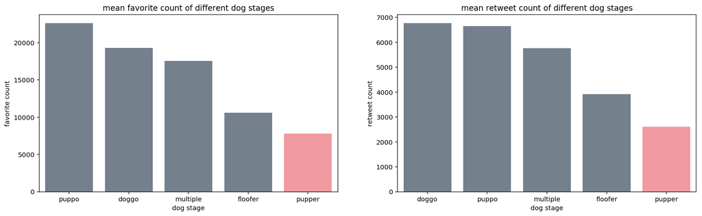

```python
popularity1 = archive.groupby('dog_stage').mean().sort_values('favorite_count', ascending = False).reset_index()
popularity2 = archive.groupby('dog_stage').mean().sort_values('retweet_count', ascending = False).reset_index()

clrs = ['#ff8b94' if (x in list(popularity1.dog_stage.tail(1))) else base_color for x in popularity1.dog_stage]

plt.figure(figsize=(18, 5))
plt.subplot(1, 2, 1)
sns.barplot(data = popularity1, x = 'dog_stage', y = 'favorite_count',\
            palette = clrs, order = popularity1.dog_stage, ci = False)
plt.ylabel('favorite count')
plt.xlabel('dog stage')
plt.title('mean favorite count of different dog stages');

plt.subplot(1, 2, 2)
sns.barplot(data = popularity2, x = 'dog_stage', y = 'retweet_count',\
            palette = clrs, order = popularity2.dog_stage, ci = False)
plt.ylabel('retweet count')
plt.xlabel('dog stage')
plt.title('mean retweet count of different dog stages');
```

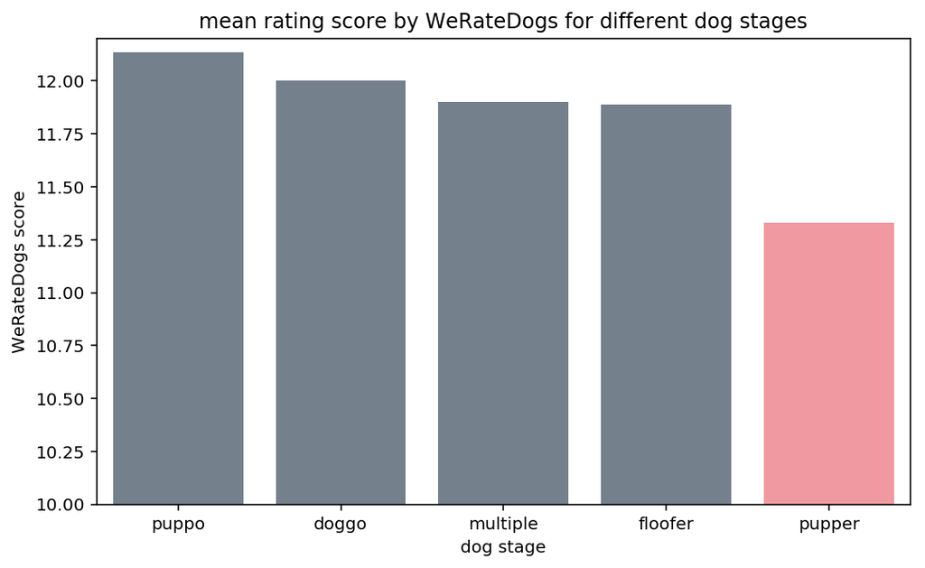

```python
rating1 = archive.groupby('dog_stage').mean().sort_values('rating_numerator', ascending = False).reset_index()
clrs = ['#ff8b94' if (x in list(rating1.dog_stage.tail(1))) else base_color for x in rating1.dog_stage]

plt.figure(figsize=(8.5, 5))
sns.barplot(data = rating1, x = 'dog_stage', y = 'rating_numerator',\
            order = rating1.dog_stage, palette = clrs, ci = False)
plt.ylim(10, 12.2)
plt.ylabel('WeRateDogs score')
plt.xlabel('dog stage')
plt.title('mean rating score by WeRateDogs for different dog stages');
```

Interesting! Puppers are the most tweeted dog stages but they receive the on average lowest rating score and are also the least popular considering both favorite and retweet count. Popularity is where doggos puppos and tweets with multiple dog stages specified start to shine as they own the highest mean score for both favorite and retweet count. So there's no point in rushing your pupper to pose for a nice image as life experience is likely to help him perform lovely lovely more valued by the community.

Enough graphs for now, let's have a look at the most popular tweets of all time and see what made them so special.

```python
top5_index = archive.favorite_count.nlargest(5).index # get index of top 5 tweets
top5 = archive[['tweet_id', 'rating_numerator', 'dog_stage', 'favorite_count',\
                'retweet_count', 'text']].iloc[top5_index]

top_tweet_ids = top5.tweet_id # get tweet ids of top 5 tweets to query predictions df
top_tweet_ids = list(top_tweet_ids) # convert to list
top5pred = predictions[predictions['tweet_id'].isin(top_tweet_ids)] # query predictions df
top5pred = top5pred[top5pred['confidence_order'] == 1] # only consider top predictions

def plt_tweet(text, archive_index, prediction_index):
    print(text)
    print('Tweet Text: ' + top5.text.loc[archive_index])
    print('Favorite count: ' + str(top5.favorite_count.loc[archive_index]))
    print('Retweet count: ' + str(top5.retweet_count.loc[archive_index]))
    print('Prediction: ' + top5pred.prediction[prediction_index])
    return Image(url = top5pred.jpg_url.loc[prediction_index], width = 250)

plt_tweet('Top Tweet', 788, 2409)
```

```
Top Tweet
Tweet Text: Here's a doggo realizing you can stand in a pool. 13/10 enlightened af (vid by Tina Conrad)
Favorite count: 164239
Retweet count: 83629
Prediction: Labrador_retriever
```

[figure not shown]

```python
plt_tweet('2nd most popular tweet', 322, 3699)
```

```
2nd most popular tweet
Tweet Text: Here's a super supportive puppo participating in the Toronto  #WomensMarch today. 13/10
Favorite count: 140342
Retweet count: 47683
Prediction: Lakeland_terrier
```

[figure not shown]

```python
plt_tweet('3rd most popular tweet', 414, 3432)
```

```
3rd most popular tweet
Tweet Text: This is Stephan. He just wants to help. 13/10 such a good boy
Favorite count: 126982
Retweet count: 60955
Prediction: Chihuahua
```

[figure not shown]

#### Conclusion

What makes the top three most popular tweets so special is not the dog stage, neither is it the dog breed. What makes those tweets stand out is that they depict a unique (and funny) scene. You will probably agree with me that you could exchange any of the dog dog breeds depicted in the Top 3 images with any other because its the action of a dog standing in a swimming pool or swiping the floor that made those tweets stand out.

I therefore want to end this analyses by stating that although several dog breeds and dog stages receive on average different ratings, the ones that really stand out are those depicting a unique moment. So don't worry if your dog breed is not among the on average Top 10 or 20 most loved breeds, it's all about having your camera ready when your dog is about to perform another funny move.